# Explore and summarize data (Red wine quality) by Edgar Eguia

**I check that my current directory is set correctly (directory where data set is stored). I display directory’s files list to get data set file name (wineQualityReds.csv) and load csv file into a dataframe (pf).**

```
## [1] "C:/Users/Edgar/Desktop/Nanodegree Data Analyst/Projects/Explore and Summarize Data"
```

```
## [1] "diamondsExample_2016-05.html" "EDA_RedWineQuality.Rmd"
## [3] "template.rmd"                 "wineQualityReds.csv"
```

**I display dataframe column/variables names. I see that first column/variable (x) is a number associated to each observation (let’s say an id in csv file) so I will not consider this column/variable in my analysis.**

```
##  [1] "X"                    "fixed.acidity"        "volatile.acidity"
##  [4] "citric.acid"          "residual.sugar"       "chlorides"
##  [7] "free.sulfur.dioxide"  "total.sulfur.dioxide" "density"
## [10] "pH"                   "sulphates"            "alcohol"
## [13] "quality"
```

**I display dataframe column/variables names. I don’t consider x column/variable in my dataframe so I create a new dataframe without x column/variable.**

```
##  [1] "fixed.acidity"        "volatile.acidity"     "citric.acid"
##  [4] "residual.sugar"       "chlorides"            "free.sulfur.dioxide"
##  [7] "total.sulfur.dioxide" "density"              "pH"
## [10] "sulphates"            "alcohol"              "quality"
```

**A few dataframe rows are shown below to have an idea of columns/variables information.**

```
##   fixed.acidity volatile.acidity citric.acid residual.sugar chlorides
## 1           7.4             0.70        0.00            1.9     0.076
## 2           7.8             0.88        0.00            2.6     0.098
## 3           7.8             0.76        0.04            2.3     0.092
## 4          11.2             0.28        0.56            1.9     0.075
## 5           7.4             0.70        0.00            1.9     0.076
## 6           7.4             0.66        0.00            1.8     0.075
##   free.sulfur.dioxide total.sulfur.dioxide density   pH sulphates alcohol
## 1                  11                   34  0.9978 3.51      0.56     9.4
## 2                  25                   67  0.9968 3.20      0.68     9.8
## 3                  15                   54  0.9970 3.26      0.65     9.8
## 4                  17                   60  0.9980 3.16      0.58     9.8
## 5                  11                   34  0.9978 3.51      0.56     9.4
## 6                  13                   40  0.9978 3.51      0.56     9.4
##   quality
## 1       5
## 2       5
## 3       5
## 4       6
## 5       5
## 6       5
```

**Which chemical property influence quality of red wines?? will be the question that I will answer by performing EDA.**

# UNIVARIATE SUMMARIES AND PLOTS SECTION.

**Summary of statistics for quality variable is provided.**

```
##    Min. 1st Qu.  Median    Mean 3rd Qu.    Max.
##   3.000   5.000   6.000   5.636   6.000   8.000
```

**Quality frequencies (0 to 10) in dataframe are shown in histogram. Qualities 0, 1, 2, 9 and 10 are not assigned to any wine. Qualities 5 and 6 show larger wine counts meaning that most of the wines are average quality. I can see that quality follows approximately a normal distribution with discrete values.**

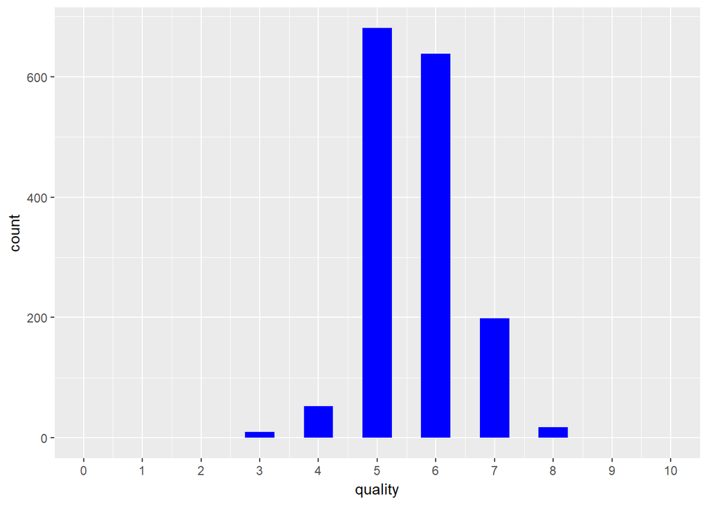

**Summary of statistics for fixed acidity variable is provided.**

```
##    Min. 1st Qu.  Median    Mean 3rd Qu.    Max.
##    4.60    7.10    7.90    8.32    9.20   15.90
```

**Fixed acidity frequencies in dataframe are shown in histogram. The distribution shown below has a positive skew and this observation matches what I’ve got at the summary above (Mean is larger than the median). 50% of wines have fixed acidity between 7.10 and 9.20 according to summary (1st Qu. to 3rd Qu.)**

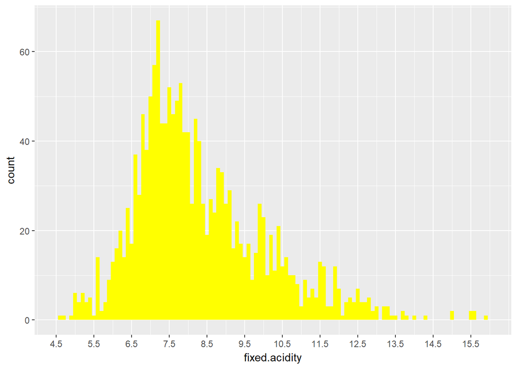

**Summary of statistics for volatile acidity variable is provided.**

```
##    Min. 1st Qu.  Median    Mean 3rd Qu.    Max.
##  0.1200  0.3900  0.5200  0.5278  0.6400  1.5800
```

**Volatile acidity frequencies in dataframe are shown in histogram. The distribution shown below is approximately normal and this observation matches what I’ve got at the summary above (Mean is approximately equal to the median). 50% of wines have volatile acidity between 0.39 and 0.64 according to summary (1st Qu. to 3rd Qu.)**

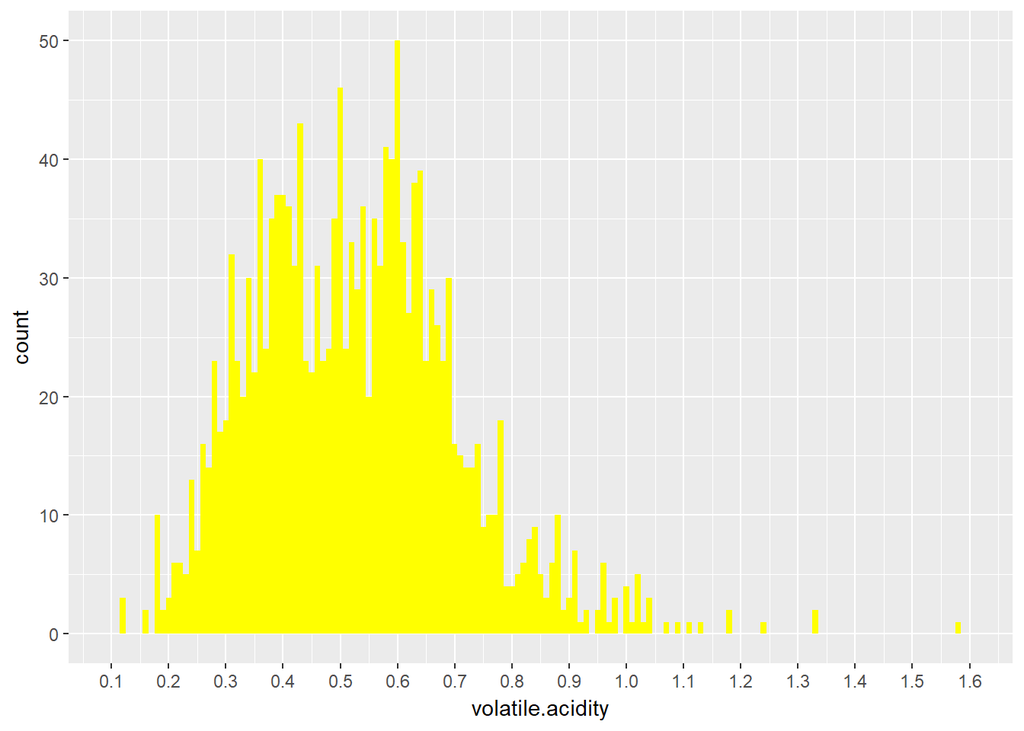

**Summary of statistics for citric acid variable is provided.**

```
##    Min. 1st Qu.  Median    Mean 3rd Qu.    Max.
##   0.000   0.090   0.260   0.271   0.420   1.000
```

**Citric acid frequencies in dataframe are shown in histogram. This distribution is interesting because Its shape is irregular. No statement about median and mean is made. 50% of wines have citric acid between 0.09 and 0.42 according to summary (1st Qu. to 3rd Qu.)**

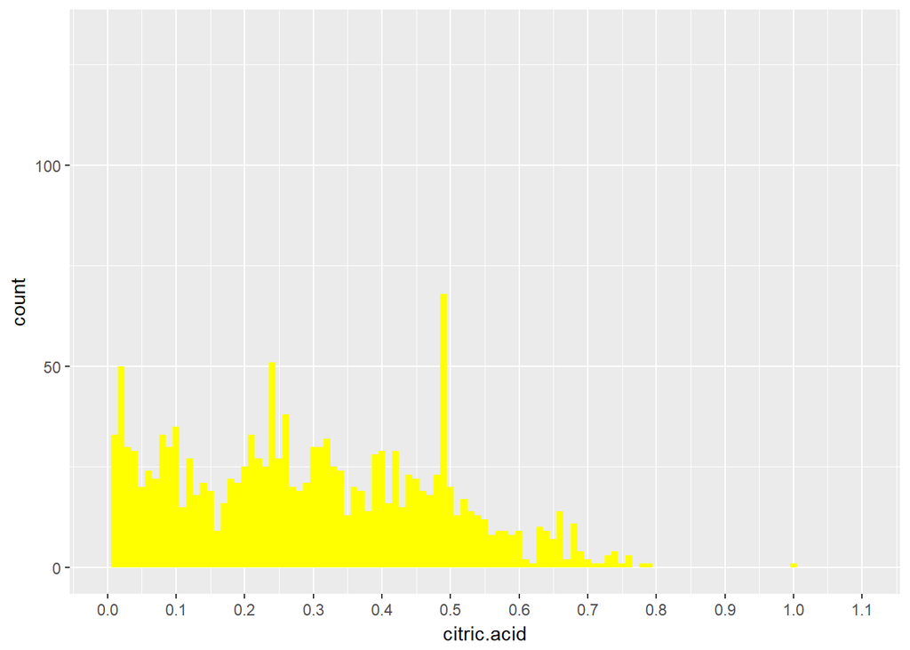

**Summary of statistics for residual sugar variable is provided.**

```
##    Min. 1st Qu.  Median    Mean 3rd Qu.    Max.
##   0.900   1.900   2.200   2.539   2.600  15.500
```

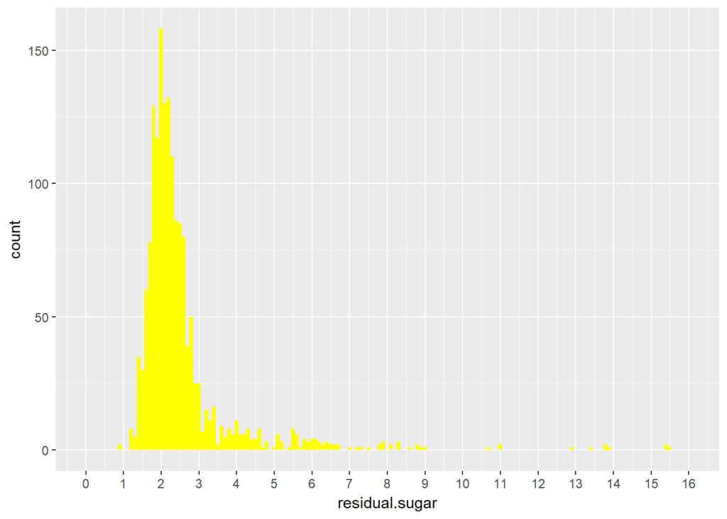

**Summary of statistics for chlorides variable is provided.**

```
##    Min. 1st Qu.  Median    Mean 3rd Qu.    Max.
## 0.01200 0.07000 0.07900 0.08747 0.09000 0.61100
```

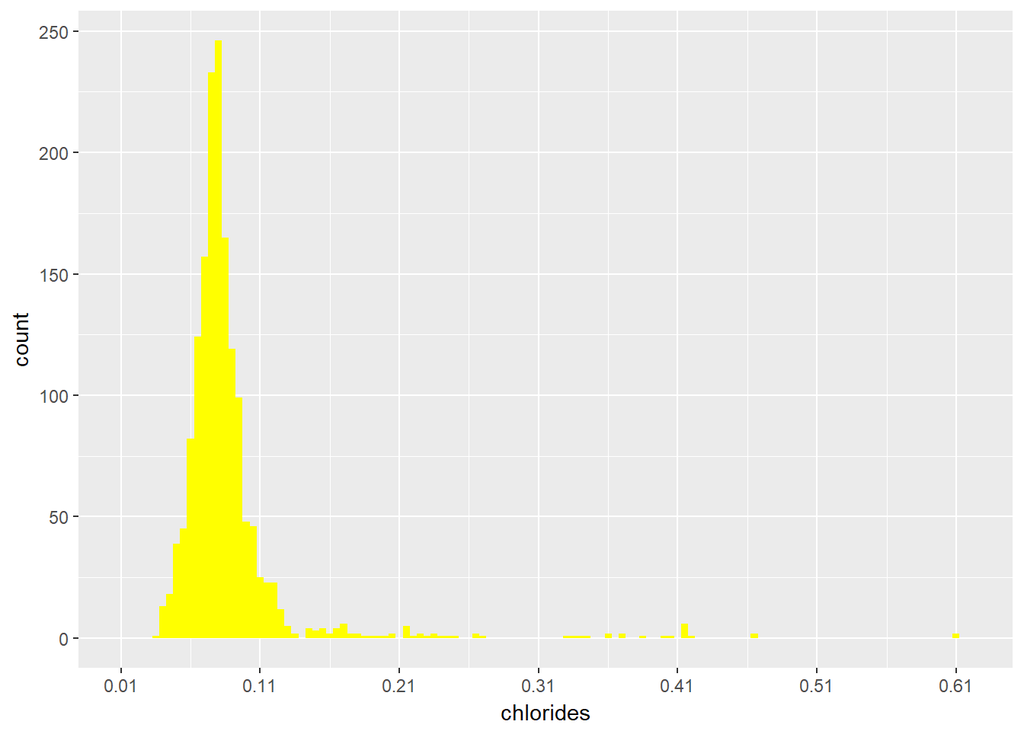

**Summary of statistics for free sulfur dioxide variable is provided.**

```
##    Min. 1st Qu.  Median    Mean 3rd Qu.    Max.
##    1.00    7.00   14.00   15.87   21.00   72.00
```

**Free sulfur dioxide frequencies in dataframe are shown in histogram. The distribution shown below has a positive skew and this observation matches what I’ve got at the summary above (Mean is larger than the median). 50% of wines have free sulfur dioxide between 7 and 21 according to summary (1st Qu. to 3rd Qu.)**

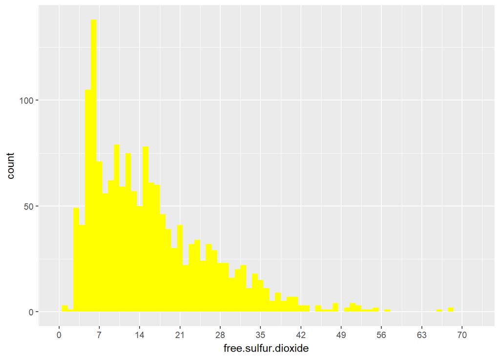

**Summary of statistics for total sulfur dioxide variable is provided.**

```
##    Min. 1st Qu.  Median    Mean 3rd Qu.    Max.
##    6.00   22.00   38.00   46.47   62.00  289.00
```

**Total sulfur dioxide frequencies in dataframe are shown in histogram. The distribution shown below has a positive skew and this observation matches what I’ve got at the summary above (Mean is larger than the median). 50% of wines have total sulfur dioxide between 22 and 62 according to summary (1st Qu. to 3rd Qu.)**

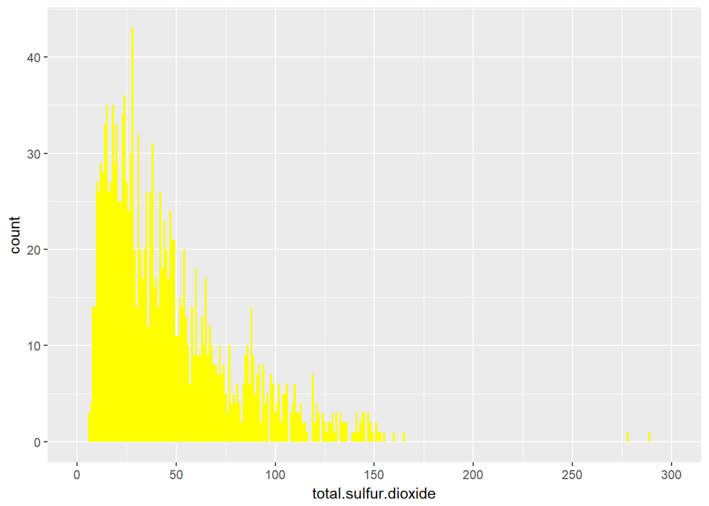

**Summary of statistics for density variable is provided.**

```
##    Min. 1st Qu.  Median    Mean 3rd Qu.    Max.
##  0.9901  0.9956  0.9968  0.9967  0.9978  1.0037
```

**Density frequencies in dataframe are shown in histogram. The distribution shown below is approximately normal and this observation matches what I’ve got at the summary above (Mean is approximately equal to the median). 50% of wines have density between 0.996 and 0.998 according to summary (1st Qu. to 3rd Qu.)**

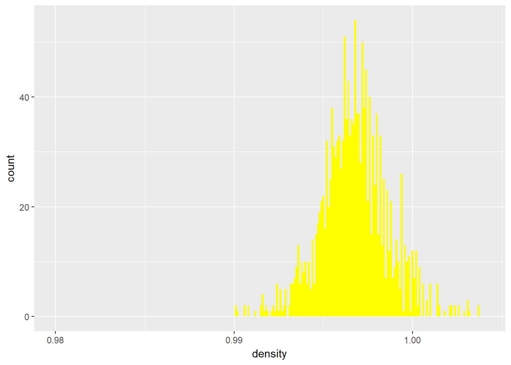

**Summary of statistics for pH variable is provided.**

```
##    Min. 1st Qu.  Median    Mean 3rd Qu.    Max.
##   2.740   3.210   3.310   3.311   3.400   4.010
```

**pH frequencies in dataframe are shown in histogram. The distribution shown below is approximately normal and this observation matches what I’ve got at the summary above (Mean is approximately equal to the median). 50% of wines have pH between 3.21 and 3.40 according to summary (1st Qu. to 3rd Qu.)**

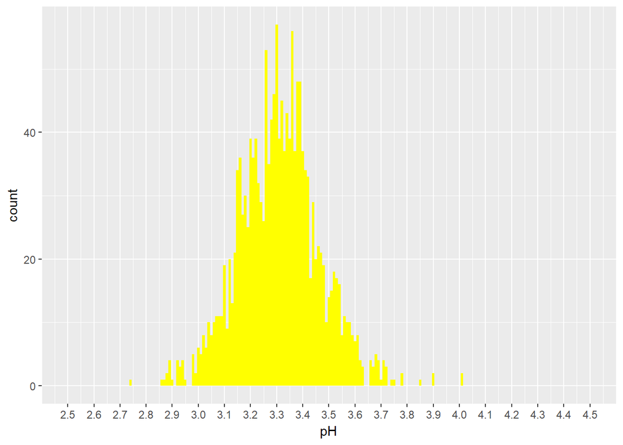

**Summary of statistics for sulphates variable is provided.**

```
##    Min. 1st Qu.  Median    Mean 3rd Qu.    Max.
##  0.3300  0.5500  0.6200  0.6581  0.7300  2.0000
```

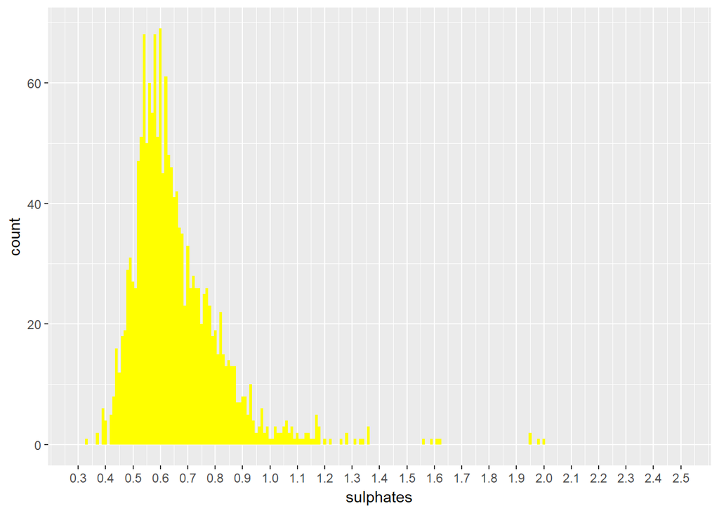

**Summary of statistics for alcohol variable is provided.**

```
##    Min. 1st Qu.  Median    Mean 3rd Qu.    Max.
##    8.40    9.50   10.20   10.42   11.10   14.90
```

**Alcohol frequencies in dataframe are shown in histogram. The distribution shown below has a positive skew and this observation matches what I’ve got at the summary above (Mean is larger than the median). 50% of wines have alcohol between 9.50 and 11.10 according to summary (1st Qu. to 3rd Qu.)**

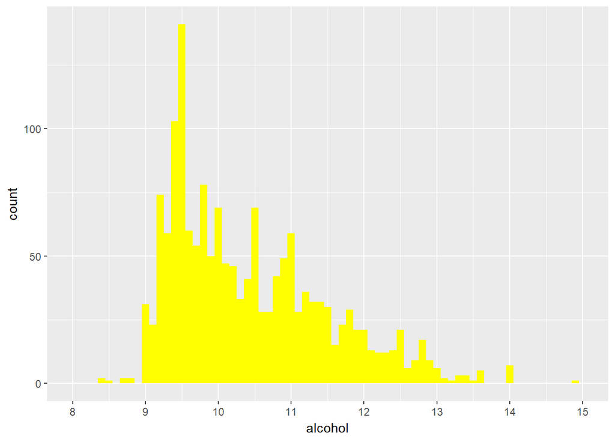

**Histogram shows wines quality distribution considering categorical values. Qualities have been grouped in bad (<=4), average (>4 & <=6) and good (>6).**

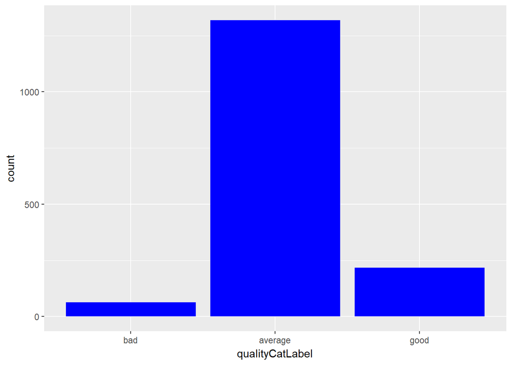

**Summary of wines quality distribution considering categorical values.**

```
##     bad average    good
##      63    1319     217
```

# Univariate Analysis

### What is the structure of your dataset?

**This dataframe contains 1,599 red wines with 11 variables about chemical properties and 1 variable about quality for each wine. Wines have been rated (a grade to the quality of each wine has been provided). Grades go from 0 to 10 (0 is very bad) and (10 is very excellent).**

### What is/are the main feature(s) of interest in your dataset?

**Quality is the main feature of interest. I want to know features/variables that influence wine quality the most.**

### What other features in the dataset do you think will help support your investigation into your feature(s) of interest?

**So far I wouldn’t know what features/variables support my investigation. I think I need to wait for bivariate analysis and multivariate analysis in order to determine which ones impact the quality of wines. I don’t know anything about wines so I would feel more confident in my analysis until displaying at least bivariate visualizations.**

### Did you create any new variables from existing variables in the dataset?

**I create 3 categorical values related to qualities.**

### Of the features you investigated, were there any unusual distributions? Did you perform any operations on the data to tidy, adjust, or change the form of the data? If so, why did you do this?

**Unusual distributions: Fixed acidity, Free sulfur dioxide, Total sulfur dioxide and Alcohol distributions are skewed to the right. Citric acid distribution is not skewed and it’s not normal either.**

# Bivariate Plots Section

**Correlation matrix is shown. I can observe an estimate of correlation coefficients values thanks to circle sizes and color palette. Pearson correlation coefficient is used by default. corrplot command is used to compute the matrix.**

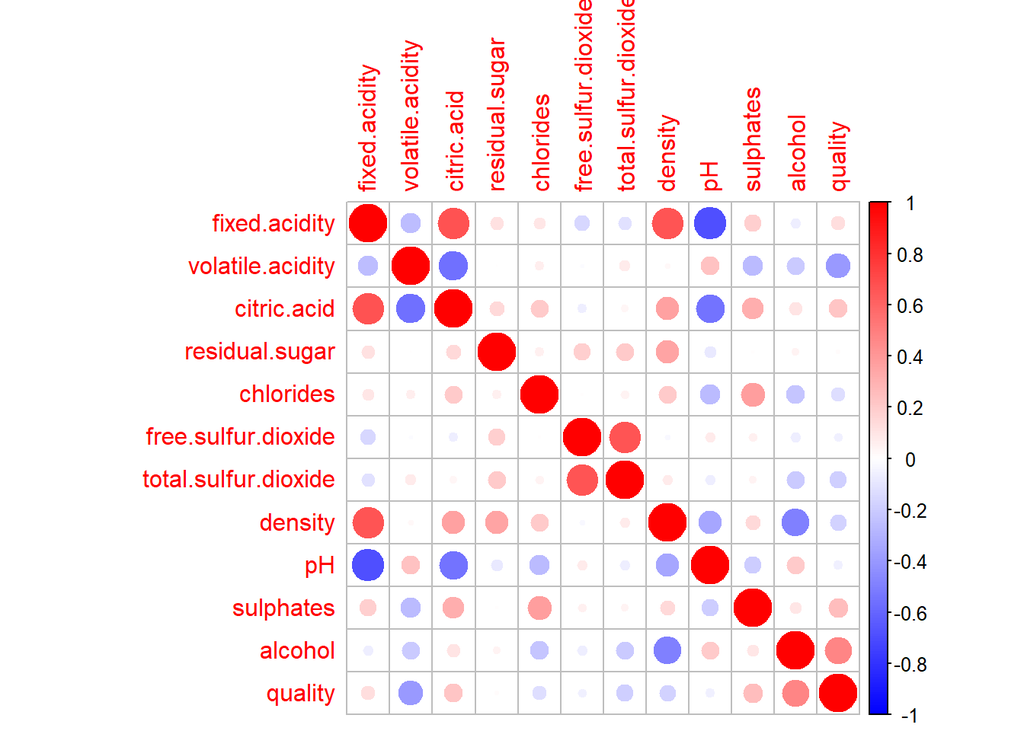

**Correlation matrix is shown. I can observe correlation coefficients values. Pearson correlation coefficient is used by default. ggcorr command is used to compute the matrix.**

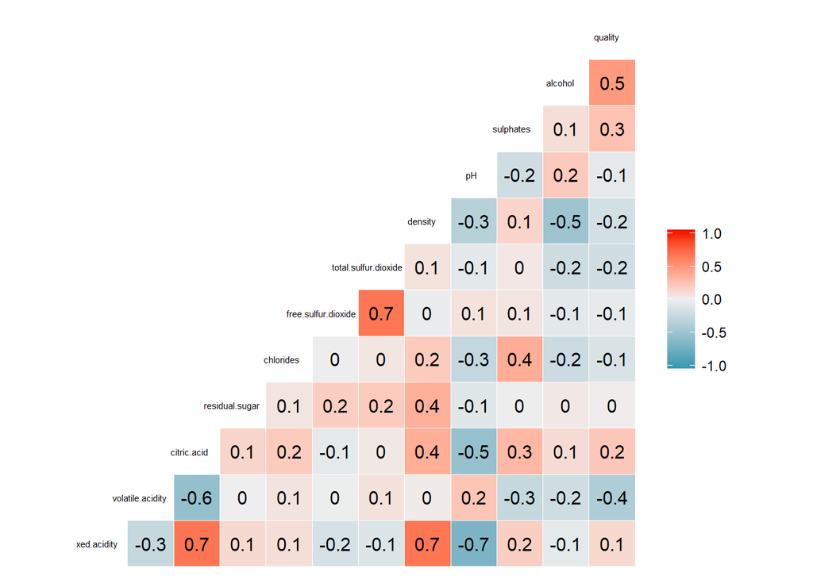

**Correlation matrices above indicate me that there are positive correlations (>=0.5) among fixed acidity and citric acid, fixed acidity and density, and free sulfur dioxide and total sulfur dioxide; on the other hand there are negative correlation (<=-0.5) among fixed acidity and pH, volatile acidity and citric acid, citric acid and pH, and density and alcohol.**

**Highest and lowest correlation coefficients found in correlation matrices are considered for quality, then I will plot alcohol vs quality, sulphates vs quality and volatile acidity vs quality.**

**Scatter plot (fixed acidity vs citric acid). Trend shows that as citric acid value increases fixed acidity value also increases.**

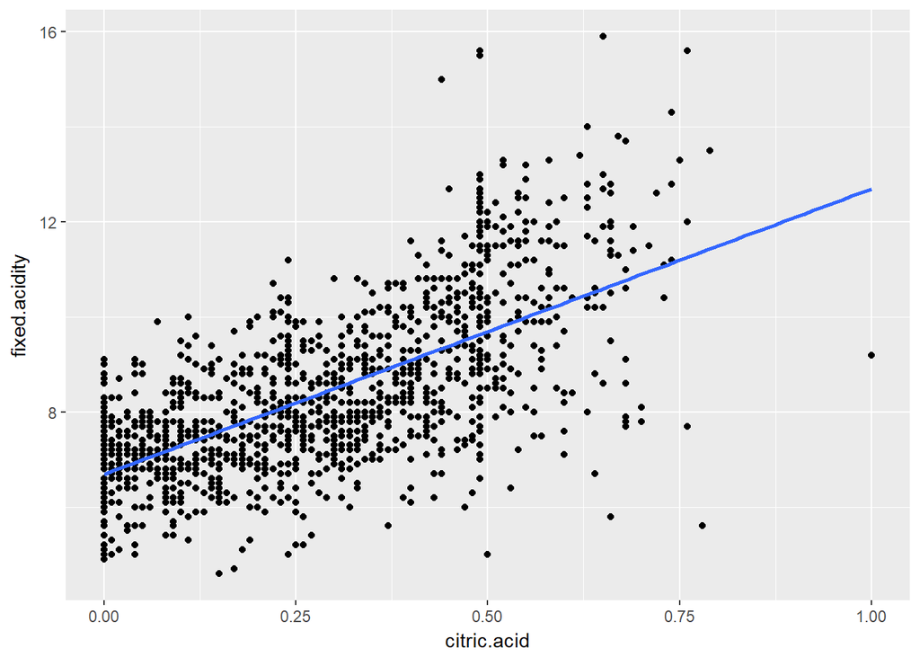

**Scatter plot (fixed acidity vs density). Trend shows that as density value increases fixed acidity value also increases.**

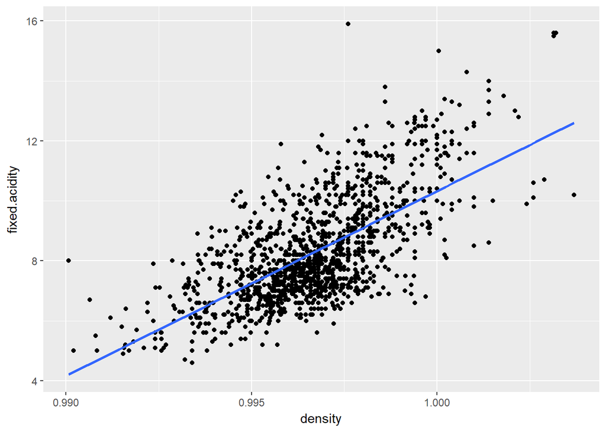

**Scatter plot (free sulfur dioxide vs total sulfur dioxide). Trend shows that as total sulfur dioxide value increases free sulfur dioxide value also increases.**

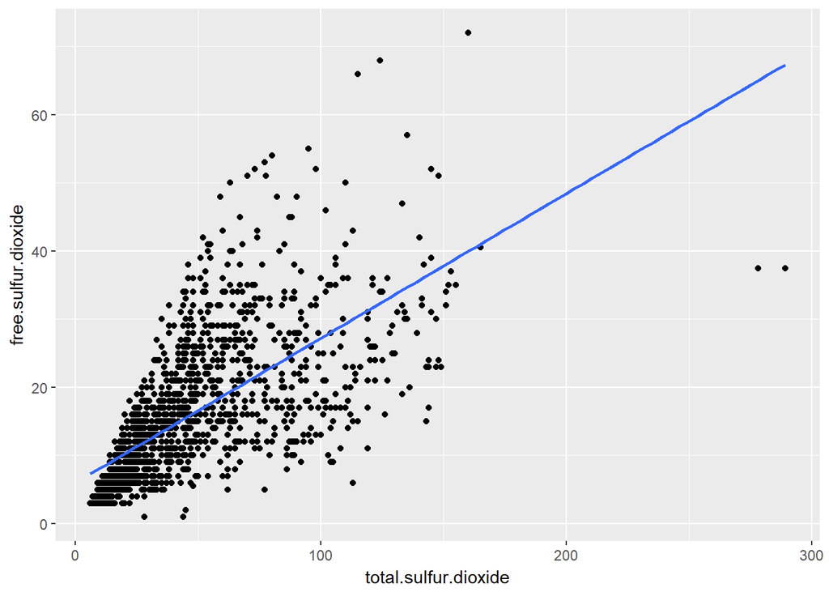

**Scatter plot (fixed acidity vs pH). Trend shows that as pH value increases fixed acidity value decreases.**

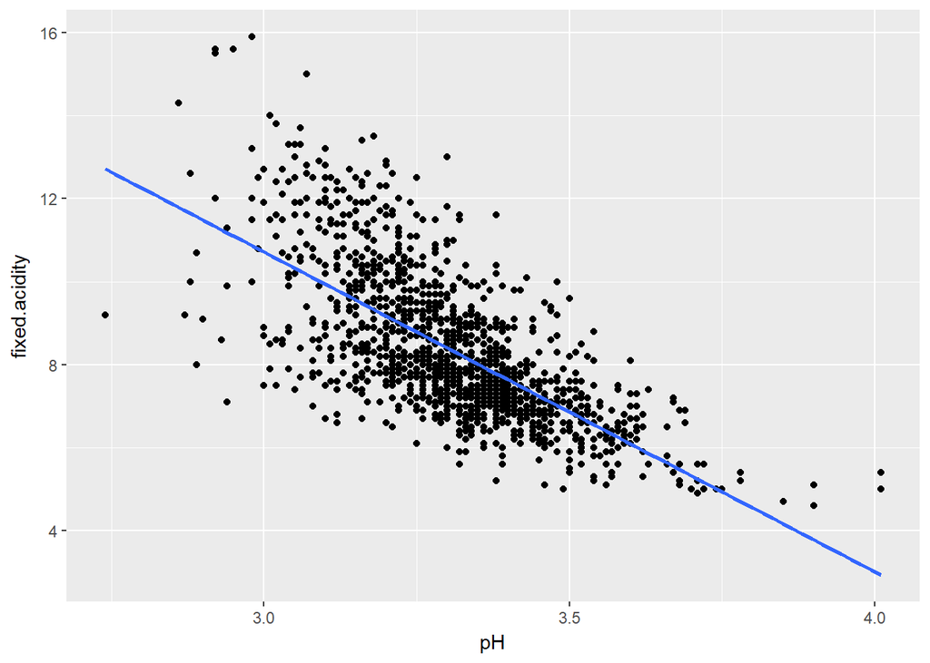

**Scatter plot (volatile acidity vs citric acid). Trend shows that as citric acid value increases volatile acidity value decreases.**

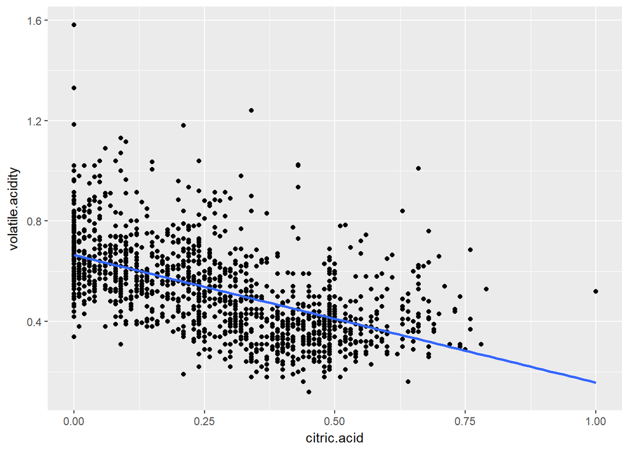

**Scatter plot (citric acid vs pH). Trend shows that as pH value increases citric acid value decreases.**

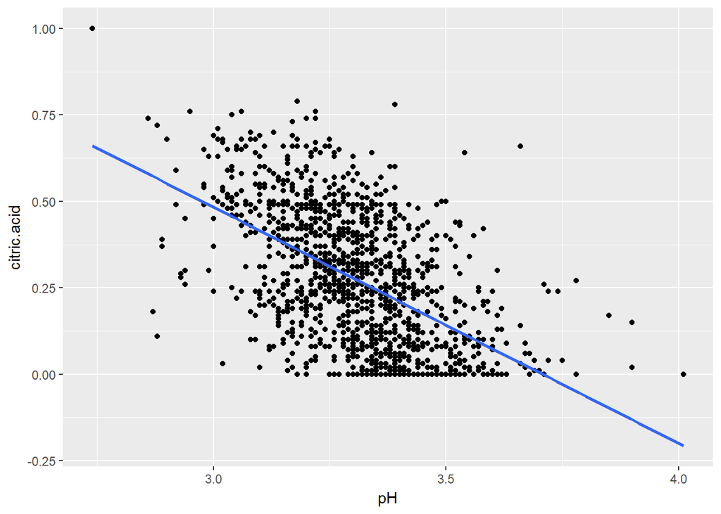

**Scatter plot (density vs alcohol). Trend shows that as alcohol value increases density value decreases.**

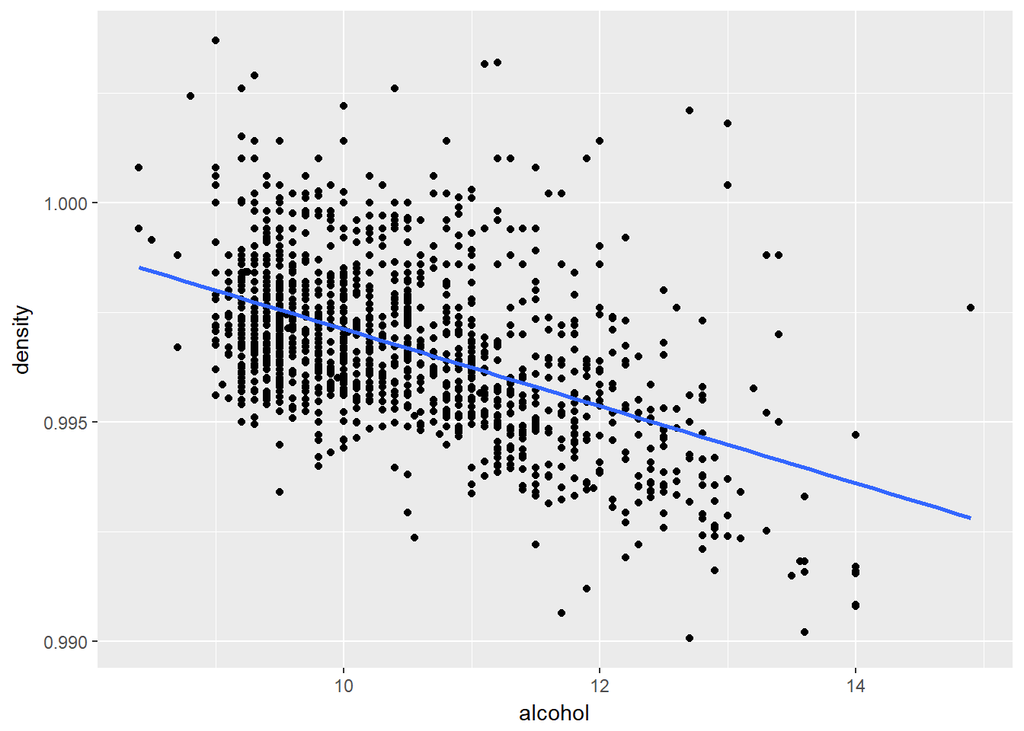

**Box plot (alcohol vs quality). Trend shows that as quality value increases alcohol median value also increases (this only happens for qualities 5 to 8). Qualities 3 to 4 show approximately a constant trend. Correlation among these variables is positive (0.5 / according to correlation matrix).**

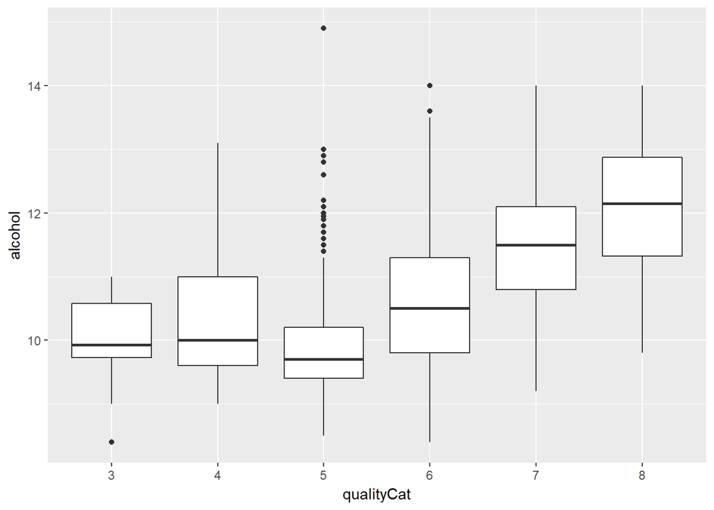

**Box plot (sulphates vs quality). Trend shows that as quality value increases sulphates median value also increases (this only happens for qualities 5 to 8). Qualities 3 to 4 show approximately a constant trend. Correlation among these variables is positive (0.3 / according to correlation matrix).**

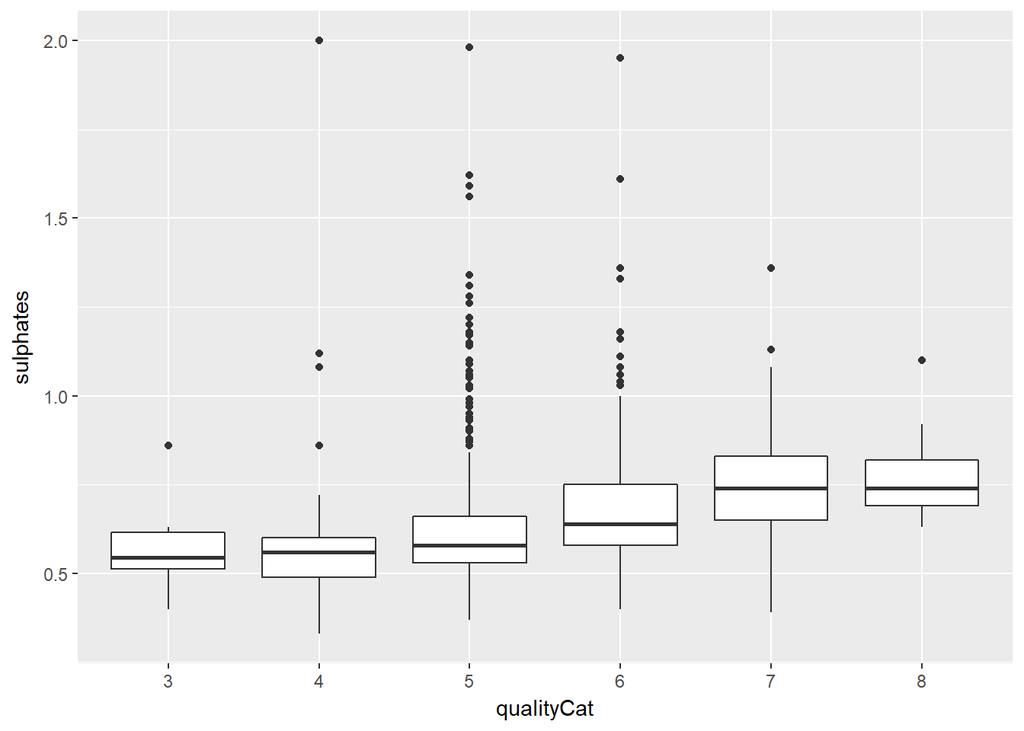

**Box plot (volatile acidity vs quality). Trend shows that as quality value increases volatile acidity median value decreases. Correlation among these variables is negative (-0.4 / according to correlation matrix).**

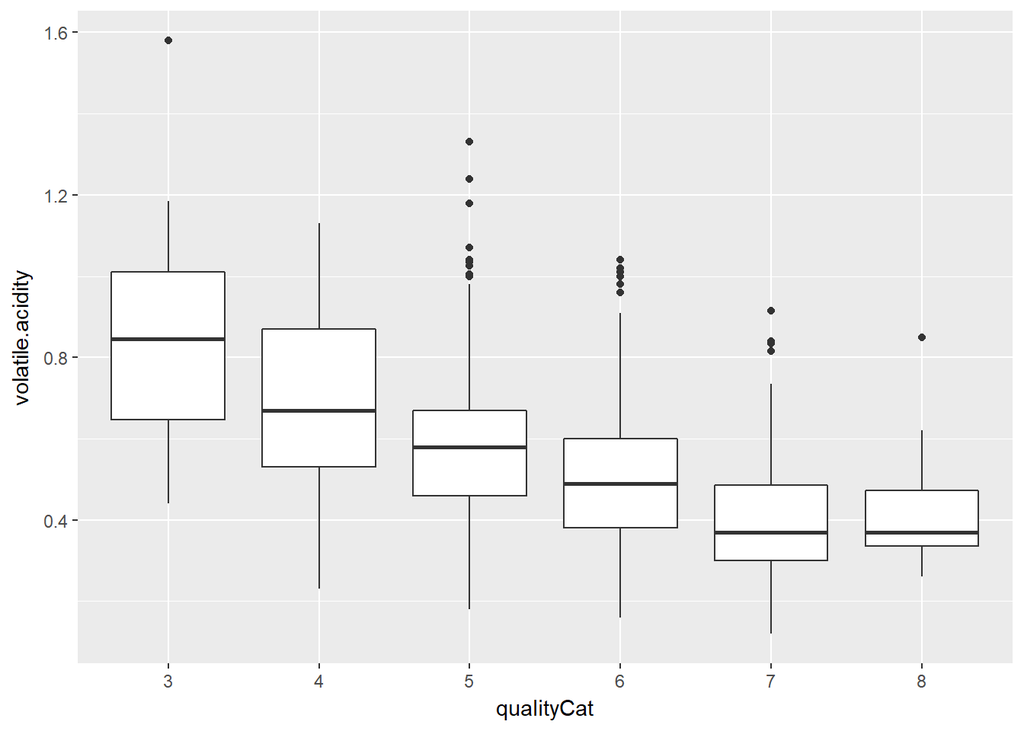

# Bivariate Analysis

### Talk about some of the relationships you observed in this part of the investigation. How did the feature(s) of interest vary with other features in the dataset?

**Looking at correlation matrices I can observe that quality (feature/variable of interest) has a mid-strong positive correlation with alcohol (0.5) and a mid negative correlation with volatile acidity (-0.4). These are the “higher” values between quality and any other variable for positive and negative correlation respectively. From box plots above I can see that quality improves considerably with higher alcohol levels, and slightly with higher sulphates quantities. Quality is affected with lower volatile acidity levels.**

### Did you observe any interesting relationships between the other features (not the main feature(s) of interest)?

**Correlation matrices show me that there are 3 strong positive correlations (0.7) and 1 strong negative correlation (-0.7)**

### What was the strongest relationship you found?

**Fixed acidity vs citric acid (0.7), fixed acidity vs density (0.7), fixed acidity vs pH (-0.7) and free sulfur dioxide vs total sulfur dioxide (0.7).**

# Multivariate Plots Section

**Scatter plot (fixed acidity vs citric acid). Trend shows that as citric acid value increases fixed acidity value also increases. I also can see quality assigned to each one of the points plotted, this way I can determine trends for quality and variables plotted if any. Actually It would be better to consider qualities grouped as bad, average and good cause there are too many categories right now (3 to 8) and this doesn’t let me visualize any trend.**

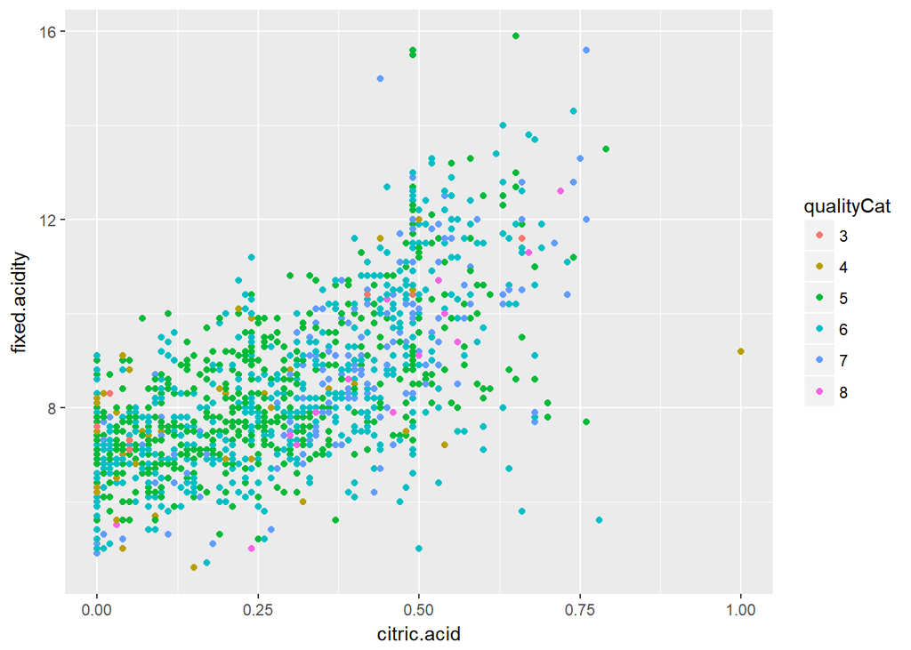

**Scatter plot (fixed acidity vs citric acid). Trend shows that as citric acid value increases fixed acidity value also increases. Qualities have been grouped in bad, average and good. Second degree polynomial fitting is used to reveal trends per quality groups. I can observe that good quality wines have lower levels of fixed acidity than average and bad quality wines considering same citric acid levels when citric acid level is below 0.50, above this level good quality wines have higher levels of fixed acidity than average and bad quality wines considering same citric acid levels. Points in scatterplot have been faded away to improve visualization.**

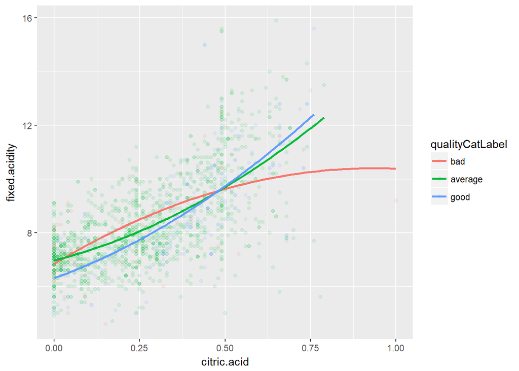

**Scatter plot (fixed acidity vs density). Trend shows that as density value increases fixed acidity value also increases. I also can see quality assigned to each one of the points plotted, this way I can determine trends for quality and variables plotted if any. Actually It would be better to consider qualities grouped as bad, average and good cause there are too many categories right now (3 to 8) and this doesn’t let me visualize any trend.**

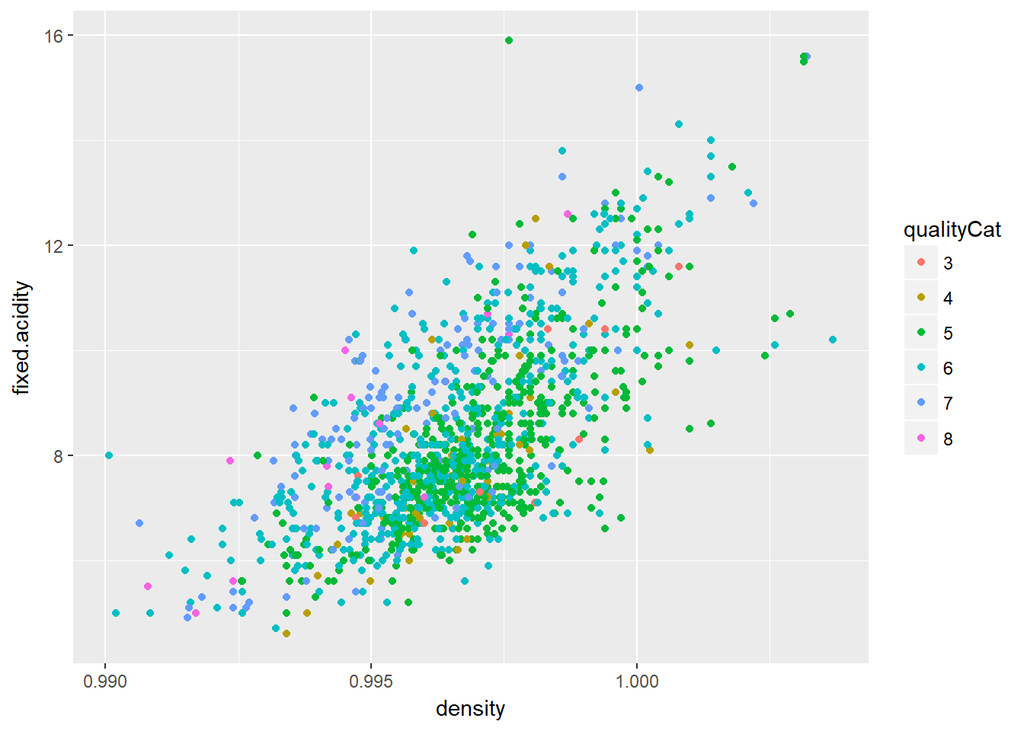

**Scatter plot (fixed acidity vs density). Trend shows that as density value increases fixed acidity value also increases. Qualities have been grouped in bad, average and good. Second degree polynomial fitting is used to reveal trends per quality groups. I can observe that good quality wines have higher fixed acidity levels than average and bad quality wines considering same densities. Points in scatterplot have been faded away to improve visualization.**

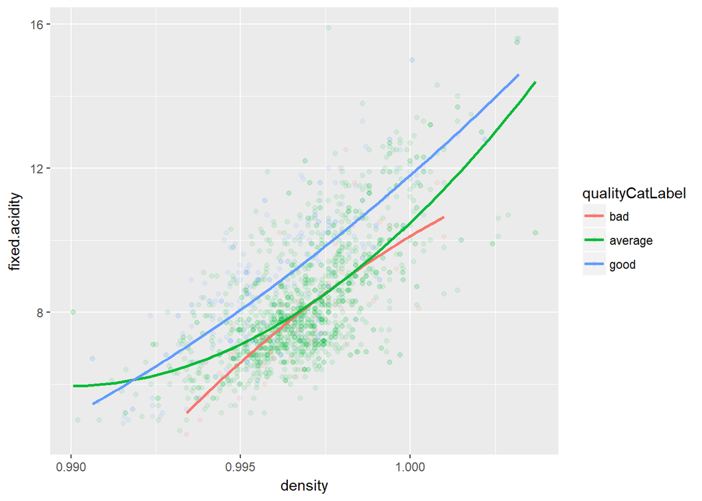

**Scatter plot (free sulfur dioxide vs total sulfur dioxide). Trend shows that as total sulfur dioxide value increases free sulfur dioxide value also increases. I also can see quality assigned to each one of the points plotted, this way I can determine trends for quality and variables plotted if any. Actually It would be better to consider qualities grouped as bad, average and good cause there are too many categories right now (3 to 8) and this doesn’t let me visualize any trend.**

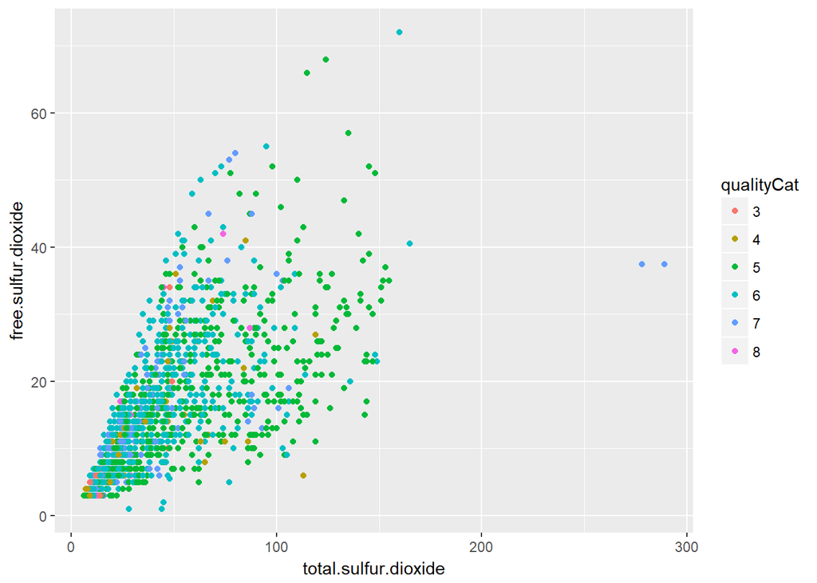

**Scatter plot (free sulfur dioxide vs total sulfur dioxide). Trend shows that as total sulfur dioxide value increases free sulfur dioxide value also increases. Qualities have been grouped in bad, average and good. Second degree polynomial fitting is used to reveal trends per quality groups. I can observe that good quality wines have higher free sulfur dioxide levels than average and bad quality wines considering same total sulfur dioxide levels. Points in scatterplot have been faded away to improve visualization.**

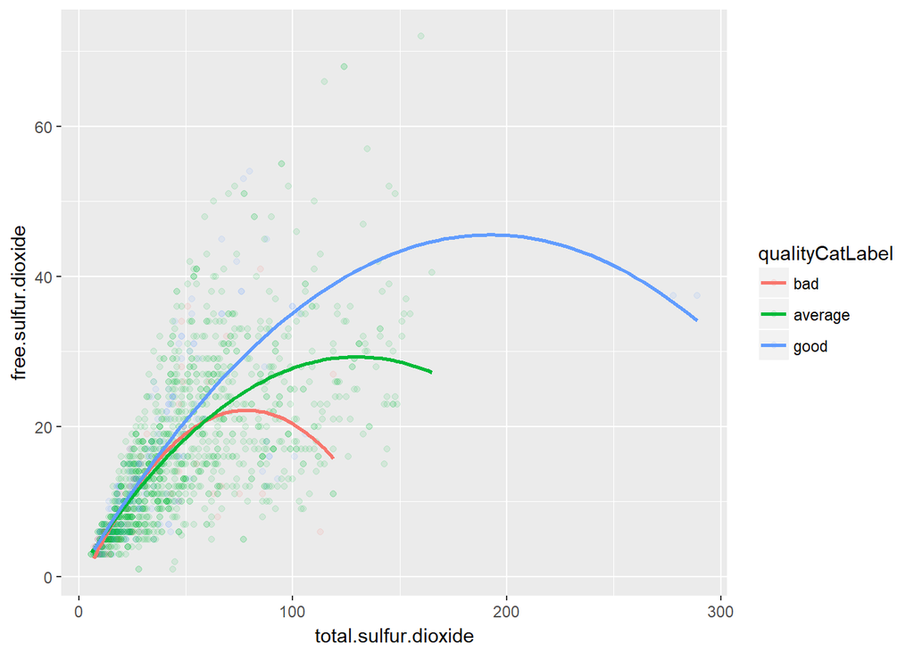